# Emperor Project

Frederik Johannsen

2022-12-27

# Setup

## Preparation before the visualisation

### First i need to install the packages needed for my project

```r
install.packages("tidyverse", repos = "https://cran.r-project.org/web/packages/tidyverse/index.html")
```

```r
install.packages("ggplot2", repos = "https://cran.r-project.org/web/packages/ggplot2/index.html")
install.packages("dplyr", repos = "https://cran.r-project.org/web/packages/dplyr/index.html")
install.packages("tidyr", repos = "https://cran.r-project.org/web/packages/tidyr/index.html")
```

### Then i activate the packages using this script

```r
library(tidyverse)
```

```r
library(ggplot2)
library(dplyr)
library(tidyr)
```

### Then i read in the dataset, originally “Life and death of Roman Emperors” by Felipe Oliveira on Kaggle, which i have cleaned using Openrefine

```r
imperator <- read_csv("data/imperator.csv")
```

# Viusalization

## Plotting the birth provinces of the emperors onto a ggplot

### Firstly i will plot the birth_province on to a geom_bar to get an overview of the data

#### The first part of this code, for excluding the NA values, is from fafa.pereira on Stackoverflow.com:https://stackoverflow.com/questions/17216358/eliminating-nas-from-a-ggplot

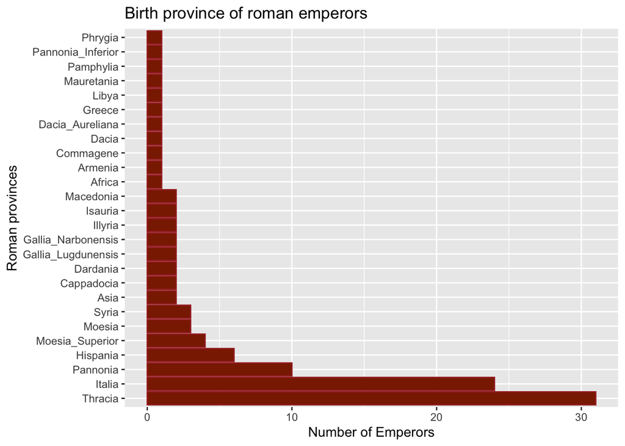

```r
ggplot(data=subset(imperator, !is.na(birth_province))) +
  geom_bar(mapping = aes(y = reorder(birth_province, birth_province, function(y)-length(y))), color = "brown",fill = "orangered4") +
  labs(x = "Number of Emperors", y = "Roman provinces", title = "Birth province of roman emperors")
```

### From this it is clear that the Italy and Thracia have produced the greater part of Augusti. What is not clear is if there is some development over time in where the emperors have originated from.

### Therefore, i will make a visualsation of the trend throughout the period of the roman and byzantine empire

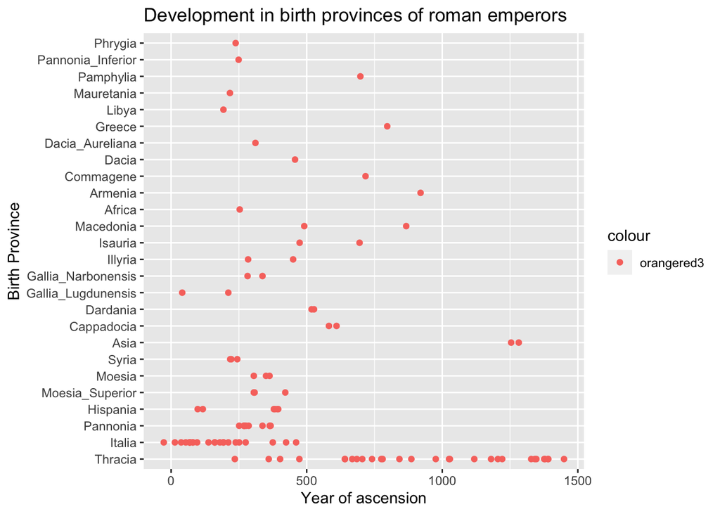

```r
ggplot(data=subset(imperator, !is.na(birth_province))) +
  geom_point(mapping = aes(x = start_of_reign, y = reorder(birth_province, birth_province, function(y)-length(y)), color = "orangered3")) +
  labs(x = "Year of ascension", y = "Birth Province", title = "Development in birth provinces of roman emperors")
```

# Conclusion

## With a look at the plot a development is immediately clear. A move away from the imperial heartland of Italy around the turn of the 3rd century. The next few centuries sees the greatest spread of emperors. The illyrians of the third century crises. The severan dynasty with the first Syrian emperors and so on. After the fall of the west, the east is clearly centralised around Constantinople in the province of Thracia.